# Activity Data Review

Russell Husfeld

May 24, 2016

## Loading and preprocessing the data

Show any code that is needed to

Load the data (i.e. read.csv())

Process/transform the data (if necessary) into a format suitable for your analysis

```r
activity <- read.csv("~/Documents/activity.csv")
str(activity)
```

```
## 'data.frame':    17568 obs. of  3 variables:
##  $ steps   : int  NA NA NA NA NA NA NA NA NA NA ...
##  $ date    : Factor w/ 61 levels "2012-10-01","2012-10-02",..: 1 1 1 1 1 1 1 1 1 1 ...
##  $ interval: int  0 5 10 15 20 25 30 35 40 45 ...
```

```r
#convert the date into Date formate "Y-m-d"
activity$date <- as.Date(activity$date,"%Y-%m-%d")
#check to make sure integer to date class has changed.
str(activity)
```

```
## 'data.frame':    17568 obs. of  3 variables:
##  $ steps   : int  NA NA NA NA NA NA NA NA NA NA ...
##  $ date    : Date, format: "2012-10-01" "2012-10-01" ...
##  $ interval: int  0 5 10 15 20 25 30 35 40 45 ...
```

```r
activity$steps <- as.numeric(activity$steps)
library(dplyr)
```

For this part of the assignment, you can ignore the missing values in the dataset.

Make a histogram of the total number of steps taken each day

Calculate and report the mean and median total number of steps taken per day

```r
activity.date<- activity %>%
  group_by(date) %>%
  summarize(tsteps=sum(steps, na.rm=TRUE))
library(lattice)
```

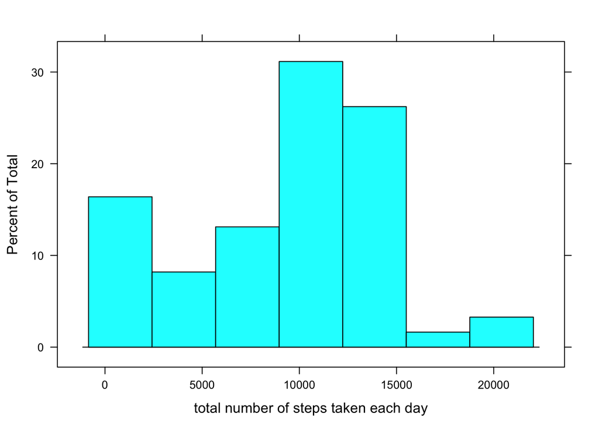

```r
histogram(~activity.date$tstep, xlab="total number of steps taken each day")
```

```r
meansteps<- mean(activity.date$tsteps)
mediansteps<- median(activity.date$tsteps)
print(meansteps)
```

```
## [1] 9354.23
```

```r
print(mediansteps)
```

```
## [1] 10395
```

## What is the average daily activity pattern?

Make a time series plot (i.e. type = “l”) of the 5-minute interval (x-axis) and the average number of steps taken, averaged across all days (y-axis)

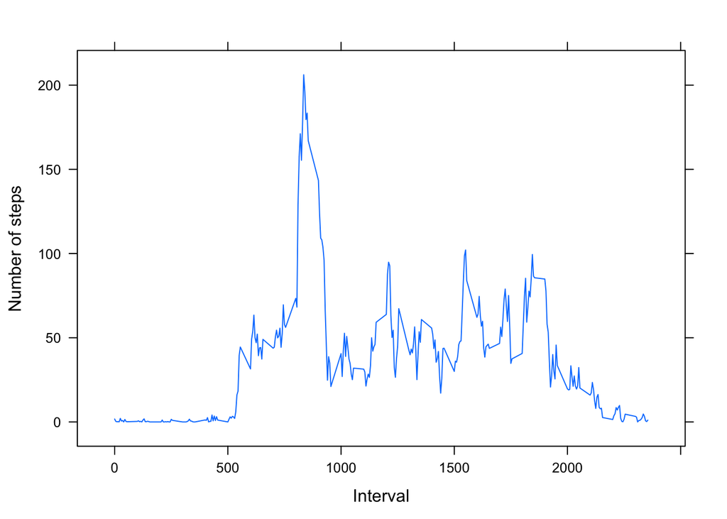

```r
activityint<- activity %>%
  group_by(interval) %>%
  summarize(tsteps=sum(steps, na.rm=TRUE), avgsteps=mean(steps, na.rm=TRUE))

with(activityint, xyplot(avgsteps~interval, type="l", xlab="Interval", ylab="Number of steps"))
```

Which 5-minute interval, on average across all the days in the dataset, contains the maximum number of steps?

```r
maxint<- which.max(activityint$tsteps)
activityint[maxint, ]
```

```
## Source: local data frame [1 x 3]
##
##   interval tsteps avgsteps
##      (int)  (dbl)    (dbl)
## 1      835  10927 206.1698
```

Calculate and report the total number of missing values in the dataset (i.e. the total number of rows with NAs)

```r
missing.values<- sum(is.na(activity$steps))
missing.values
```

```
## [1] 2304
```

Devise a strategy for filling in all of the missing values in the dataset. The strategy does not need to be sophisticated. For example, you could use the mean/median for that day, or the mean for that 5-minute interval, etc.

Create a new dataset that is equal to the original dataset but with the missing data filled in.

```r
activity.replaceNA<- activity %>%
  group_by(interval)  %>%
  mutate(steps= ifelse(is.na(steps), mean(steps, na.rm=TRUE), steps))
```

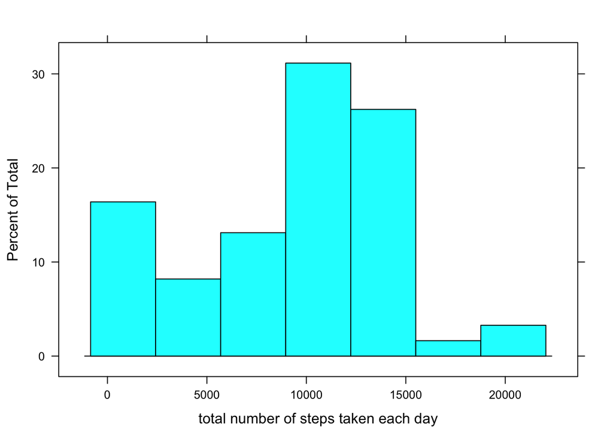

```r
histogram(activity.date$tsteps, xlab="total number of steps taken each day")
```